# Trabalho 4

Daniel Krügel

2023-02-20

Estarei testando o pacote `gtsummary` para criar as tabelas deste trabalho, portanto deixarei todos os chunks de códigos com `echo = TRUE`.

# Questão 13

## a)

A população de inferência é a população que frequenta o starbucks no período das 8:00 até as 8:30, a amostra foi quem frequenta o starbucks de Lincoln, NE.

## b)

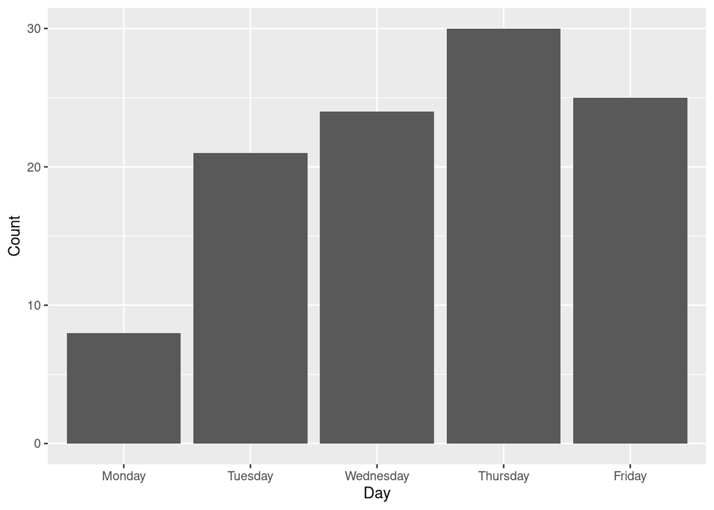

```r
starbucks$Day <- factor(starbucks$Day,
                        levels = c('Monday',"Tuesday","Wednesday","Thursday","Friday"))

starbucks %>%
  ggplot(aes(x = Day, y = Count)) +
  geom_bar(stat = "identity")
```

## c)

```r
fit1 <- glm(Count ~ Day,
            family = poisson(link='log'),
            data = starbucks)
```

```r
fit1 %>%
  tbl_regression(add_estimate_to_reference_rows = F) %>%
  add_q()
```

```
## add_q: Adjusting p-values with
## `stats::p.adjust(x$table_body$p.value, method = "fdr")`
```

| **Characteristic** | **log(IRR)**<sup>1</sup> | **95% CI**<sup>1</sup> | **p-value** | **q-value**<sup>2</sup> |
| --- | --- | --- | --- | --- |
| Day |  |  |  |  |
| Monday | — | — |  |  |
| Tuesday | 0.97 | 0.19, 1.8 | 0.020 | 0.020 |
| Wednesday | 1.1 | 0.34, 2.0 | 0.007 | 0.009 |
| Thursday | 1.3 | 0.59, 2.2 | <0.001 | 0.004 |
| Friday | 1.1 | 0.39, 2.0 | 0.005 | 0.009 |

<sup>1</sup> IRR = Incidence Rate Ratio, CI = Confidence Interval  
<sup>2</sup> False discovery rate correction for multiple testing

## I)

Lembrando que usamos a função de ligação log, então para conseguir as estimativas diárias precisamos passar um exponencial nos coeficientes.

```r
fit1 %>%
  tbl_regression(exponentiate = T) %>%
  add_global_p()
```

| **Characteristic** | **IRR**<sup>1</sup> | **95% CI**<sup>1</sup> | **p-value** |
| --- | --- | --- | --- |
| Day |  |  | 0.005 |
| Monday | — | — |  |
| Tuesday | 2.62 | 1.21, 6.31 |  |
| Wednesday | 3.00 | 1.41, 7.13 |  |
| Thursday | 3.75 | 1.80, 8.78 |  |
| Friday | 3.13 | 1.47, 7.41 |  |

<sup>1</sup> IRR = Incidence Rate Ratio, CI = Confidence Interval

## II)

```r
xtable(Anova(fit1))
```

|  | LR Chisq | Df | Pr(>Chisq) |
| --- | --- | --- | --- |
| Day | 15.00147 | 4 | 0.004698171 |

Utilizando o pacote no qual estou aprendendo a usar, o valor do teste LR é omitido, porém o p-valor é exibido a cada covariável.

```r
fit1 %>%
  tbl_regression() %>%
  add_global_p()
```

| **Characteristic** | **log(IRR)**<sup>1</sup> | **95% CI**<sup>1</sup> | **p-value** |
| --- | --- | --- | --- |
| Day |  |  | 0.005 |
| Monday | — | — |  |
| Tuesday | 0.97 | 0.19, 1.8 |  |
| Wednesday | 1.1 | 0.34, 2.0 |  |
| Thursday | 1.3 | 0.59, 2.2 |  |
| Friday | 1.1 | 0.39, 2.0 |  |

<sup>1</sup> IRR = Incidence Rate Ratio, CI = Confidence Interval

O Teste LR demonstrou que a variável `Day` é relevante para a contagem de pessoas presentes no Starbucks com um P-valor de 0.0046982

## IV)

Aqui temos a média estimada para cada dia da semana

```r
quart <- summary(starbucks$Count)
quart[4]*fit1$coefficients[1:5]
```

```
##  (Intercept)   DayTuesday DayWednesday  DayThursday    DayFriday
##     2.030416     4.169149     4.746005     5.709985     4.922356
```

E aqui vemos a média observada em cada dia da semana

```r
starbucks %>%
  group_by(Day) %>%
  reframe(total = mean(Count))
```

| Day | total |
| --- | --- |
| Monday | 1.6 |
| Tuesday | 4.2 |
| Wednesday | 4.8 |
| Thursday | 6.0 |
| Friday | 5.0 |

Os intervalos de confiança para a média de cada dia da semana:

```r
K <- matrix(data = c(1*quart[4], 0, 0, 0, 0,
                     0, 1*quart[4], 0, 0, 0,
                     0, 0, 1*quart[4], 0, 0,
                     0, 0, 0, 1*quart[4], 0,
                     0, 0, 0, 0, 1*quart[4]), nrow = 5, ncol = 5, byrow = TRUE)
linear.combo <- mcprofile(object = fit1, CM = K)
ci.beta <- confint(object = linear.combo, level = 0.95)
Estimativas <- ci.beta$confint
rownames(Estimativas) <- c("Segunda","Terça","Quarta","Quinta","Sexta")
Estimativas
```

|  | lower | upper |
| --- | --- | --- |
| Segunda | -2.1714700 | 5.206645 |
| Terça | 0.1451533 | 8.833065 |
| Quarta | 0.8236566 | 9.356882 |
| Quinta | 1.9317931 | 10.244580 |
| Sexta | 1.0286619 | 9.518169 |

## d)

Ambas as formas de escrita do teste de hipóteses descrevem um modelo linear de variáveis, porém quando levado para modelos lineares generalizados precisamos levar em conta a função de ligação utilizada no modelo. Como utilizamos a função canônica de ligação para o GLM da família Poisson, sua link é a Função logarítmica, o que deve de ser levado a diante no teste de razões LRT seria algo como:

$$H_0: e^\mu_1 = e^\mu_2 = e^\mu_3 = e^\mu_4 = e^\mu_5$$

$$H_1: \mu \neq \mu \neq \mu \neq \mu \neq \mu$$